# Homework #4

Chris Daviau true  
2022-04-10

### Question 1

(SMSS 14.3, 14.4, merged & modified)

(Data file: house.selling.price.2 from smss R package)

#### 1A For backward elimination, which variable would be deleted first? Why?

For backward elimination, Beds would be removed first since it has the largest p-value compared to the other predictors (0.487)

#### 1C Why do you think that BEDS has such a large P-value in the multiple regression model, even though it has a substantial correlation with PRICE?

I think that Beds has such a large p-value in the regression model because it is somewhat redundant information. Size its capturing the overall size of the house, including bedrooms,meaning Beds isn’t really adding anything new to the model. Beds could be highly correlated with price since more beds means larger size, but we already have Size accounting for a large portion of the variation.

#### 1D Using software with these four predictors, find the model that would be selected using each criterion: R2, Adjusted R2, PRESS, AIC, BIC

```
Call:
lm(formula = P ~ S, data = house.selling.price.2)

Residuals:
    Min      1Q  Median      3Q     Max
-56.407 -10.656   2.126  11.412  85.091

Coefficients:
            Estimate Std. Error t value Pr(>|t|)
(Intercept)  -25.194      6.688  -3.767 0.000293 ***
S             75.607      3.865  19.561  < 2e-16 ***
---
Signif. codes:  0 '***' 0.001 '**' 0.01 '*' 0.05 '.' 0.1 ' ' 1

Residual standard error: 19.47 on 91 degrees of freedom
Multiple R-squared:  0.8079,    Adjusted R-squared:  0.8058
F-statistic: 382.6 on 1 and 91 DF,  p-value: < 2.2e-16
```

```
Call:
lm(formula = P ~ S + New, data = house.selling.price.2)

Residuals:
    Min      1Q  Median      3Q     Max
-47.207  -9.763  -0.091   9.984  76.405

Coefficients:
            Estimate Std. Error t value Pr(>|t|)
(Intercept)  -26.089      5.977  -4.365 3.39e-05 ***
S             72.575      3.508  20.690  < 2e-16 ***
New           19.587      3.995   4.903 4.16e-06 ***
---
Signif. codes:  0 '***' 0.001 '**' 0.01 '*' 0.05 '.' 0.1 ' ' 1

Residual standard error: 17.4 on 90 degrees of freedom
Multiple R-squared:  0.8484,    Adjusted R-squared:  0.845
F-statistic: 251.8 on 2 and 90 DF,  p-value: < 2.2e-16
```

```
Call:
lm(formula = P ~ S + New + Ba, data = house.selling.price.2)

Residuals:
    Min      1Q  Median      3Q     Max
-34.804  -9.496   0.917   7.931  73.338

Coefficients:
            Estimate Std. Error t value Pr(>|t|)
(Intercept)  -47.992      8.209  -5.847 8.15e-08 ***
S             62.263      4.335  14.363  < 2e-16 ***
New           18.371      3.761   4.885 4.54e-06 ***
Ba            20.072      5.495   3.653 0.000438 ***
---
Signif. codes:  0 '***' 0.001 '**' 0.01 '*' 0.05 '.' 0.1 ' ' 1

Residual standard error: 16.31 on 89 degrees of freedom
Multiple R-squared:  0.8681,    Adjusted R-squared:  0.8637
F-statistic: 195.3 on 3 and 89 DF,  p-value: < 2.2e-16
```

```
Call:
lm(formula = P ~ S + New + Ba + Be, data = house.selling.price.2)

Residuals:
    Min      1Q  Median      3Q     Max
-36.212  -9.546   1.277   9.406  71.953

Coefficients:
            Estimate Std. Error t value Pr(>|t|)
(Intercept)  -41.795     12.104  -3.453 0.000855 ***
S             64.761      5.630  11.504  < 2e-16 ***
New           18.984      3.873   4.902  4.3e-06 ***
Ba            19.203      5.650   3.399 0.001019 **
Be            -2.766      3.960  -0.698 0.486763
---
Signif. codes:  0 '***' 0.001 '**' 0.01 '*' 0.05 '.' 0.1 ' ' 1

Residual standard error: 16.36 on 88 degrees of freedom
Multiple R-squared:  0.8689,    Adjusted R-squared:  0.8629
F-statistic: 145.8 on 4 and 88 DF,  p-value: < 2.2e-16
```

R2 - SNBB R2 Adj. - SNB

```
[1] 38203.29
```

```
[1] 31066
```

```
[1] 27860.05
```

```
[1] 28390.22
```

PRESS - SNB

```
[1] 820.1439
```

```
[1] 800.1262
```

```
[1] 789.1366
```

```
[1] 790.6225
```

AIC - SNB

```
[1] 827.7417
```

```
[1] 810.2566
```

```
[1] 801.7996
```

```
[1] 805.8181
```

BIC - SNB

#### 1E Explain which model you prefer and why.

I prefer the SNB model, which includes Size, New and Bath, because it seems to be the best model for almost all comparisons. It has the lowest PRESS, AIC, and BIC compared to the other models and has a larger R2 adjusted as well. The model containing all variables does have a higher R2, but only by a small margin. Bedrooms do not seem to add any additional information to the model which is why I choose the model with all except Bedrooms.

### Question 2

(Data file: trees from base R) From the documentation: “This data set provides measurements of the diameter, height and volume of timber in 31 felled black cherry trees. Note that the diameter (in inches) is erroneously labelled Girth in the data. It is measured at 4 ft 6 in above the ground.”

Tree volume estimation is a big deal, especially in the lumber industry. Use the trees data to build a basic model of tree volume prediction. In particular,

#### 2A Fit a multiple regression model withthe Volume as the outcome and Girth and Height as the explanatory variables

```
Call:
lm(formula = Volume ~ Girth + Height, data = trees)

Residuals:
    Min      1Q  Median      3Q     Max
-6.4065 -2.6493 -0.2876  2.2003  8.4847

Coefficients:
            Estimate Std. Error t value Pr(>|t|)
(Intercept) -57.9877     8.6382  -6.713 2.75e-07 ***
Girth         4.7082     0.2643  17.816  < 2e-16 ***
Height        0.3393     0.1302   2.607   0.0145 *
---
Signif. codes:  0 '***' 0.001 '**' 0.01 '*' 0.05 '.' 0.1 ' ' 1

Residual standard error: 3.882 on 28 degrees of freedom
Multiple R-squared:  0.948, Adjusted R-squared:  0.9442
F-statistic:   255 on 2 and 28 DF,  p-value: < 2.2e-16
```

#### 2B Run regression diagnostic plots on the model. Based on the plots, do you think any of the regression assumptions is violated?

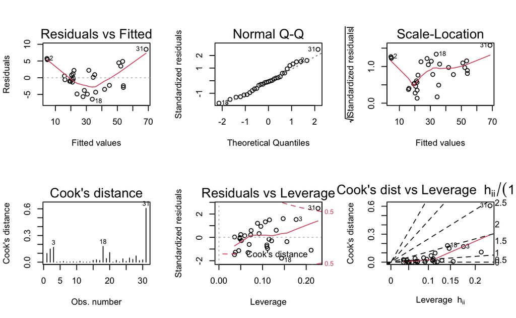

The plots suggest that there are regression assumptions being violated, specifically linearity and constant variance. The residuals do not form a straight line, violating linearity, and the residuals do not form a horizontal band, violating constant variance.

### Question 3

(inspired by ALR 9.16)

(Data file: florida in alr R package)

In the 2000 election for U.S. president, the counting of votes in Florida was controversial. In Palm Beach County in south Florida, for example, voters used a so-called butterfly ballot. Some believe that the layout of the ballot caused some voters to cast votes for Buchanan when their intended choice was Gore.

The data has variables for the number of votes for each candidate—Gore, Bush, and Buchanan. Run a simple linear regression model where the Buchanan vote is the outcome and the Bush vote is the explanatory variable. Produce the regression diagnostic plots. Is Palm Beach County an outlier based on the diagnostic plots? Why or why not?

```
Call:
lm(formula = Buchanan ~ Bush, data = florida)

Residuals:
    Min      1Q  Median      3Q     Max
-907.50  -46.10  -29.19   12.26 2610.19

Coefficients:
             Estimate Std. Error t value Pr(>|t|)
(Intercept) 4.529e+01  5.448e+01   0.831    0.409
Bush        4.917e-03  7.644e-04   6.432 1.73e-08 ***
---
Signif. codes:  0 '***' 0.001 '**' 0.01 '*' 0.05 '.' 0.1 ' ' 1

Residual standard error: 353.9 on 65 degrees of freedom
Multiple R-squared:  0.3889,    Adjusted R-squared:  0.3795
F-statistic: 41.37 on 1 and 65 DF,  p-value: 1.727e-08
```

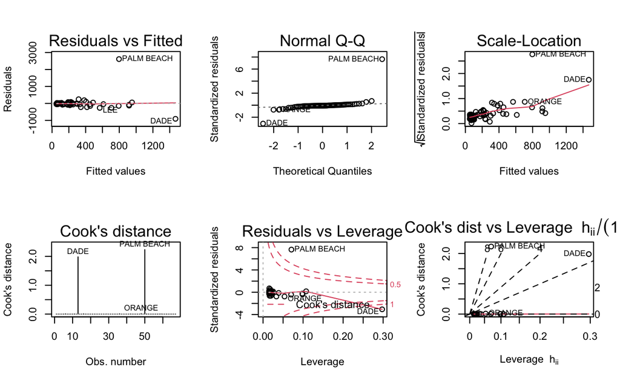

I would absolutely classify Palm Beach County as an outlier considering for a majority of the graphs, it is well outside of the rest of the observations. Palm Beach County as a single observation cannot be reasonably grouped with any of the other observations.

### PART 2 (Final Project)

#### 1 What is your research question for the final project?

I was able to find to a dataset from Kaggle that contained results from an online personality test. For the purposes of this project, the research question is: Why do most people score very high on questions relating to AGR or OPN?

#### 2 What is your hypothesis (i.e. an answer to the research question) that you want to test?

I’d like to test whether or not the time spent answering each section is the reason for this unequal categorization. If more people have AGR or OPN as their dominant trait, then they are most likely spending more time on answering questions specific to those categories.

#### 3 Present some exploratory analysis. In particular:

##### 3A Numerically summarize (e.g. with the summary() function) the variables of interest (the outcome, the explanatory variable, the control variables).

```
[1] 13996    23
```

```
# A tibble: 6 × 23
    EXT   EST   AGR   CSN   OPN Dom_Trait Weak_Trait EXT_Min EST_Min
  <dbl> <dbl> <dbl> <dbl> <dbl> <chr>     <chr>        <dbl>   <dbl>
1    14    45    39    19    44 EST       EXT          1.41    0.345
2    37    22    50    39    43 AGR       EST          0.468   0.478
3    37    29    26    21    46 OPN       CSN          0.880   0.659
4    14    30    34    36    28 CSN       EXT          2.06    2.83
5    32    39    33    17    31 EST       CSN          1.08    0.572
6    23    22    24    28    40 OPN       EST          0.629   0.402
# … with 14 more variables: AGR_Min <dbl>, CSN_Min <dbl>,
#   OPN_Min <dbl>, dateload <dttm>, screenw <dbl>, screenh <dbl>,
#   Device <chr>, Intro_Min <dbl>, Test_Min <dbl>, End_Min <dbl>,
#   IPC <dbl>, country <chr>, lat_appx_lots_of_err <chr>,
#   long_appx_lots_of_err <chr>
```

```
$EXT
[1] "numeric"

$EST
[1] "numeric"

$AGR
[1] "numeric"

$CSN
[1] "numeric"

$OPN
[1] "numeric"

$Dom_Trait
[1] "character"

$Weak_Trait
[1] "character"

$EXT_Min
[1] "numeric"

$EST_Min
[1] "numeric"

$AGR_Min
[1] "numeric"

$CSN_Min
[1] "numeric"

$OPN_Min
[1] "numeric"

$dateload
[1] "POSIXct" "POSIXt"

$screenw
```

[output cut: 13 more lines]

```

$End_Min
[1] "numeric"

$IPC
[1] "numeric"

$country
[1] "character"

$lat_appx_lots_of_err
[1] "character"

$long_appx_lots_of_err
[1] "character"
```

```
      EXT             EST             AGR             CSN
 Min.   : 9.00   Min.   :10.00   Min.   :10.00   Min.   :10.00
 1st Qu.:21.00   1st Qu.:24.00   1st Qu.:34.00   1st Qu.:29.00
 Median :27.00   Median :30.00   Median :40.00   Median :35.00
 Mean   :26.93   Mean   :30.06   Mean   :38.58   Mean   :34.43
 3rd Qu.:33.00   3rd Qu.:37.00   3rd Qu.:44.00   3rd Qu.:40.00
 Max.   :45.00   Max.   :50.00   Max.   :50.00   Max.   :50.00
      OPN         Dom_Trait          Weak_Trait
 Min.   :11.00   Length:13996       Length:13996
 1st Qu.:35.00   Class :character   Class :character
 Median :40.00   Mode  :character   Mode  :character
 Mean   :39.24
 3rd Qu.:44.00
 Max.   :50.00
    EXT_Min           EST_Min           AGR_Min
 Min.   :-0.1826   Min.   : 0.0000   Min.   :-0.3609
 1st Qu.: 0.5476   1st Qu.: 0.4510   1st Qu.: 0.4964
 Median : 0.7096   Median : 0.5840   Median : 0.6420
 Mean   : 0.9354   Mean   : 0.7449   Mean   : 0.8151
 3rd Qu.: 0.9584   3rd Qu.: 0.8002   3rd Qu.: 0.8743
 Max.   :27.9596   Max.   :26.4420   Max.   :22.5983
    CSN_Min           OPN_Min            dateload
 Min.   : 0.0000   Min.   : 0.01697   Min.   :2018-01-01 00:00:53
 1st Qu.: 0.5051   1st Qu.: 0.47053   1st Qu.:2018-01-10 04:42:29
 Median : 0.6634   Median : 0.59398   Median :2018-01-18 18:14:11
 Mean   : 0.8441   Mean   : 0.77454   Mean   :2018-01-18 02:38:16
 3rd Qu.: 0.9210   3rd Qu.: 0.79927   3rd Qu.:2018-01-26 11:26:39
 Max.   :20.8378   Max.   :93.48397   Max.   :2018-02-01 04:58:25
    screenw        screenh          Device
 Min.   :   0   Min.   :   0.0   Length:13996
 1st Qu.: 768   1st Qu.: 736.0   Class :character
 Median :1366   Median : 800.0   Mode  :character
 Mean   :1184   Mean   : 831.2
 3rd Qu.:1440   3rd Qu.: 900.0
 Max.   :1959   Max.   :2560.0
   Intro_Min           Test_Min          End_Min
 Min.   :    0.00   Min.   : 0.4167   Min.   :    0.033
 1st Qu.:    0.08   1st Qu.: 2.7000   1st Qu.:    0.150
 Median :    0.17   Median : 3.4667   Median :    0.200
 Mean   :   22.82   Mean   : 4.2094   Mean   :    4.374
 3rd Qu.:    0.48   3rd Qu.: 4.6833   3rd Qu.:    0.267
 Max.   :62074.67   Max.   :29.9167   Max.   :18956.383
      IPC          country          lat_appx_lots_of_err
 Min.   :  1.0   Length:13996       Length:13996
 1st Qu.:  1.0   Class :character   Class :character
 Median :  1.0   Mode  :character   Mode  :character
 Mean   : 13.2
 3rd Qu.:  3.0
 Max.   :276.0
 long_appx_lots_of_err
 Length:13996
 Class :character
 Mode  :character
```

##### 3B Plot the relationships between key variables. You can do this any way you want, but one straightforward way of doing this would be with the pairs() function or other scatter plots / box plots. Interpret what you see.

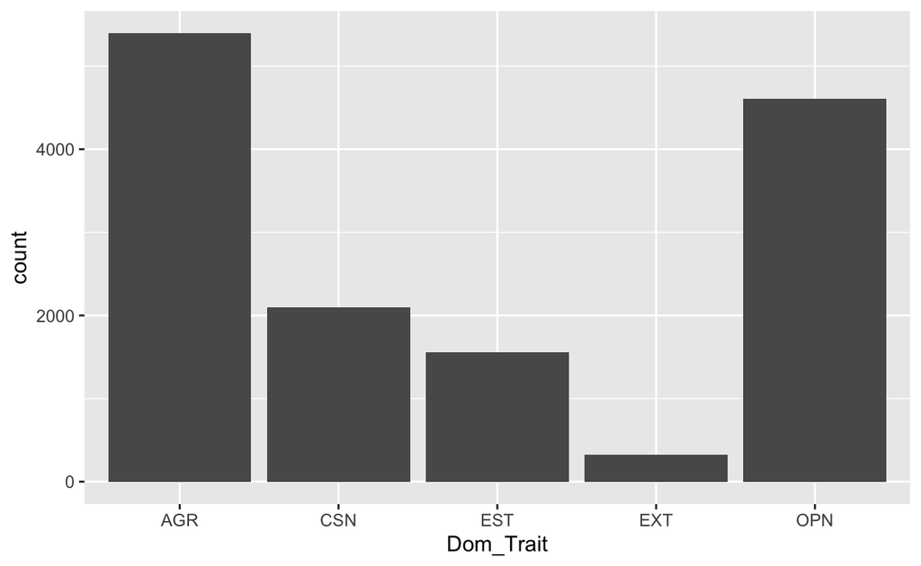

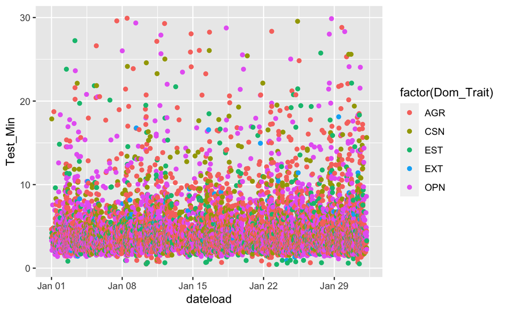

The first plot shows us that more people are classified as AGR or OPN as their dominant trait compared to the other 3 traits. This helps explain why on the second graph, the majority of observations are either purple or orange. Additionally, the second graph shows how much time it took for respondents to take the test, with a majority of participants completing the test in 5 minutes or less.